**Frequency Response**

By Prof. Seungchul Lee  
http://iai.postech.ac.kr/  
Industrial AI Lab at POSTECH

Table of Contents

# 1. Sinusoidal Steady-State Analysis

- Previously, we have determined the time response of linear systems to arbitrary inputs and initial conditions
- We have also studied the character of certain standard systems to certain simple inputs

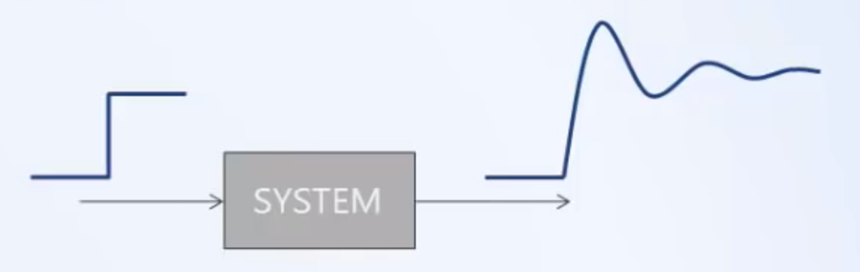

## 1.1. Response to a Sinusoidal Input

- Only focus on steady-state solution
- Transient solution is not our interest any more
- Input sine waves of different frequencies and look at the output in steady state
- If $G(s)$ is linear and stable, a sinusoidal input will generate in steady state a scaled and shifted sinusoidal output of the same frequency

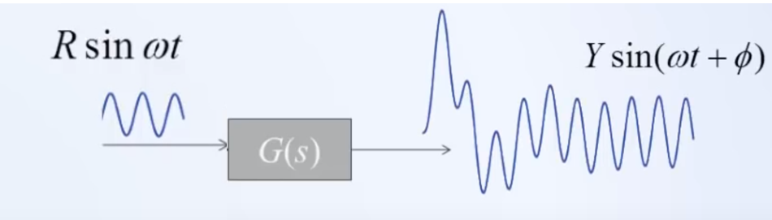

- When the input $x(t) = e^{j\omega t}$ to an LTI system

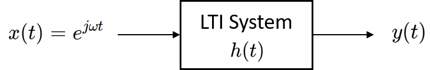

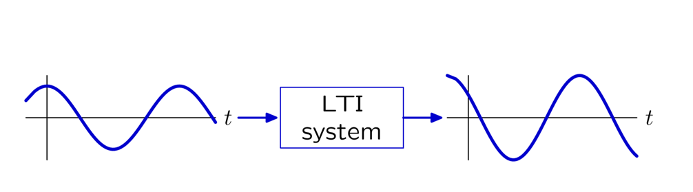

$$ \begin{align*} y(t) = h(t) * x(t) = \int^\infty_{-\infty}h(\tau)e^{j\omega(t-\tau)}d\tau &= e^{j\omega t} \underbrace{\int^\infty_{-\infty}h(\tau)e^{-j\omega \tau}d\tau}_{\text{complex function of } \omega} \\\\ &= e^{j\omega t} H(j\omega) \end{align*} $$

- Output is also a sinusoid
  - same frequency
  - possibly diﬀerent amplitude, and
  - possibly diﬀerent phase angle

## 1.2. Fourier Transform

$$H(j\omega) = \int^\infty_{-\infty}h(\tau)e^{-j\omega \tau}d\tau$$

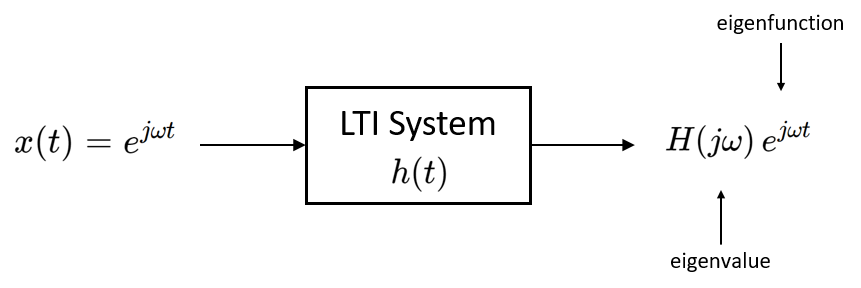

- $H(j\omega)e^{j\omega t}$ rotates with the same angular velocity $\omega$

$$H(j\omega)= \lvert H(j\omega) \rvert e^{j\angle H(j\omega)}$$

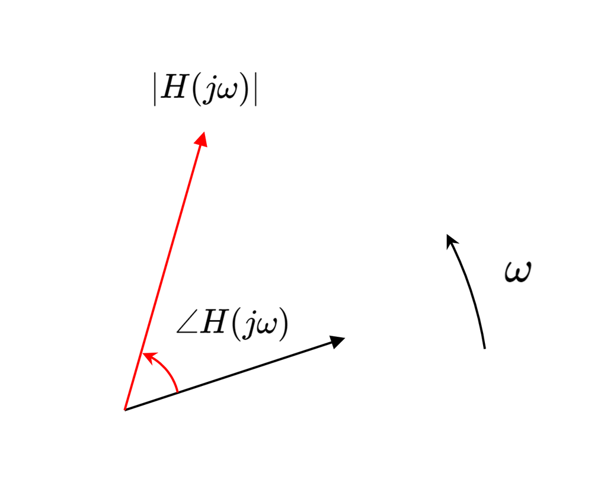

- Example

$$ \dot{y} + 5y = x(t)$$

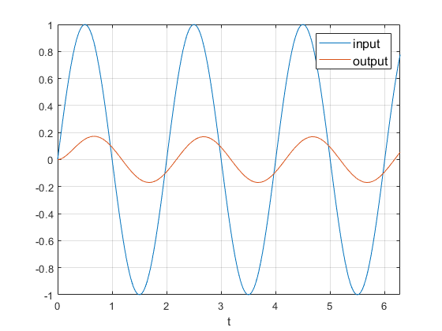

```matlab
% use lsim

A = -5;
B = 1;
C = 1;
D = 0;
G = ss(A,B,C,D);

w = pi;
t = linspace(0,2*pi,200);

x0 = 0;

x = sin(w*t);

[y,tout] = lsim(G,x,t,x0);

plot(t,x), hold on
plot(tout,y), hold off
grid on
xlabel('t')
axis tight, ylim([-1,1])
leg = legend('input','output');
set(leg, 'fontsize', 12)
```

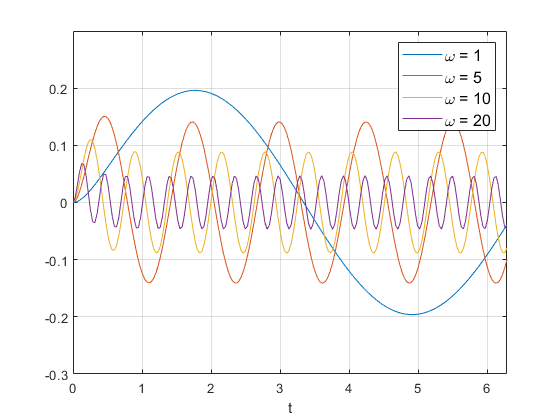

```matlab
% sinusoidal inputs with different w

A = -5;
B = 1;
C = 1;
D = 0;
G = ss(A,B,C,D);

x0 = 0;

t = linspace(0,2*pi,200);

W = [1,5,10,20];
for w = W
    x = sin(w*t);
    [y,tout] = lsim(G,x,t,x0);
    plot(tout,y), hold on
end

hold off
grid on
axis tight, ylim([-0.3,0.3])
xlabel('t')
leg = legend('\omega = 1','\omega = 5','\omega = 10','\omega = 20');
set(leg, 'fontsize', 12)
```

## 1.3. Frequency Response to a Sinsoidal Input (Frequency Sweep)

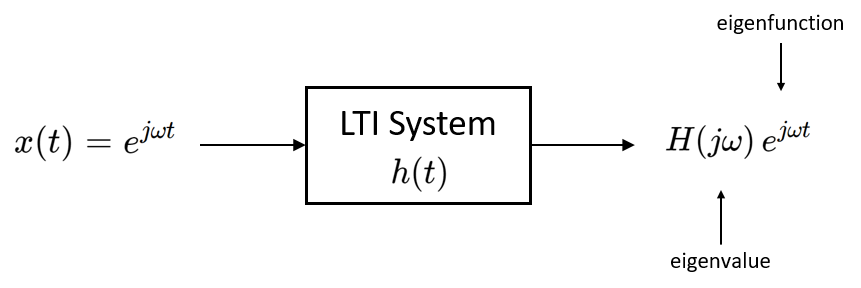

Two primary quantities of interest that have implications for system performance are:

- the scaling = magnitude of $H(j \omega)$

$$\left\lvert \frac{Y(s)}{X(s)}\right\rvert_{s=j \omega} = \lvert H(j \omega) \rvert$$

- the phase shift = angle of $H(j \omega)$

$$\phi = \angle H(j \omega)$$

Example

- Given input $ e^{j\omega t} $

$$ \begin{align*} \dot{y} + 5y &= 5x(t) \\\\ \dot{y} + 5y &= 5e^{j\omega t} \end{align*} $$

- If $ y = Ae^{j(\omega t + \phi)} $

$$ \begin{align*} j\omega A e^{j(\omega t + \phi)} + 5Ae^{j(\omega t + \phi)} &= 5e^{j\omega t}\\ \left( j\omega + 5 \right)Ae^{j\phi} &= 5\\ \end{align*} $$

- Therefore,

$$ \begin{align*} \lvert H(j\omega) \rvert = A &= \frac{5}{\mid {j\omega + 5}\mid} \\ \angle H(j\omega) = \phi &= -\angle{(j\omega + 5)} \end{align*} $$

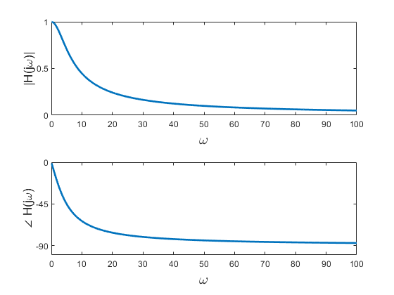

```matlab
w = 0.1:0.1:100;

A = 5./abs(1j*w+5);
P = -angle(1j*w+5)*180/pi;

subplot(2,1,1), plot(w, A, 'linewidth', 2)
yticks([0,0.5,1])
ylabel('|H(j\omega)|', 'fontsize', 13)
xlabel('\omega', 'fontsize', 15)

subplot(2,1,2), plot(w, P, 'linewidth', 2)
yticks([-90, -45, 0])
ylabel('\angle H(j\omega)', 'fontsize', 13)
xlabel('\omega', 'fontsize', 15)

% later, we will see that this is kind of a bode plot
```

# 2. From Laplace Transform to Fourier Transform

## 2.1. Eigenfunctions and Eigenvalues

If the output signal is a scalar multiple of the input signal, we refer to the signal as an eigenfunction and the multiplier as the eigenvalue.

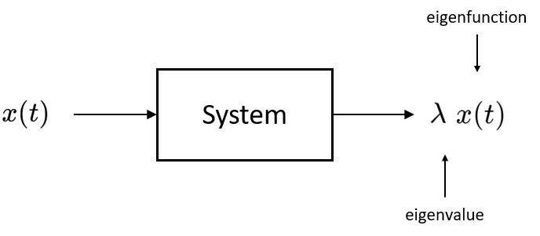

Fact: complex exponentials are eigenfunctions of LTI systems

- If $x(t) = e^{st}$ and $h(t)$ is the impulse response then,

$$ \begin{align*} y(t) &= h(t) * x(t) = \int_{-\infty}^{\infty} h(\tau) e^{s(t-\tau)} \, d\tau = e^{st}\int_{-\infty}^{\infty} h(\tau) e^{-s\tau} \, d\tau = \underbrace{H(s)}_{\text{eigenvalue}} e^{st} \\\\ H(s) &= \int_{-\infty}^{\infty}h(\tau) e^{-s\tau} d \tau \end{align*}$$

- The eigenvalue associated with eigenfunction $e^{st}$ is $H(s)$

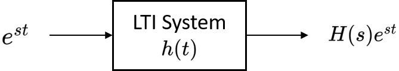

## 2.2. Rational Transfer Functions

- Eigenvalues are particularly easy to evaluate for systems represented by linear differential equations with constant coefficients.
- Then the system function is a ratio of polynomials in $s$
- Example

$$\ddot y(t) + 3 \dot y(t) + 4 y(t) = 2 \ddot x(t) + 7 \dot x(t) + 8 x(t)$$

$$H(s) = \frac{2s^2 + 7s + 8}{s^2 + 3s + 4}$$

## 2.3. Vector Diagrams

- The value of $H(s)$ at a point $s = s_0$ can be determined graphically using vectorial analysis.
- Factor the numerator and denominator of the system function to make poles and zeros explicit.

$$H(s_0) = K \frac{(s_0 - z_0)(s_0 - z_1)(s_0 - z_2)\cdots}{(s_0 - p_0)(s_0 - p_1)(s_0 - p_2)\cdots}$$

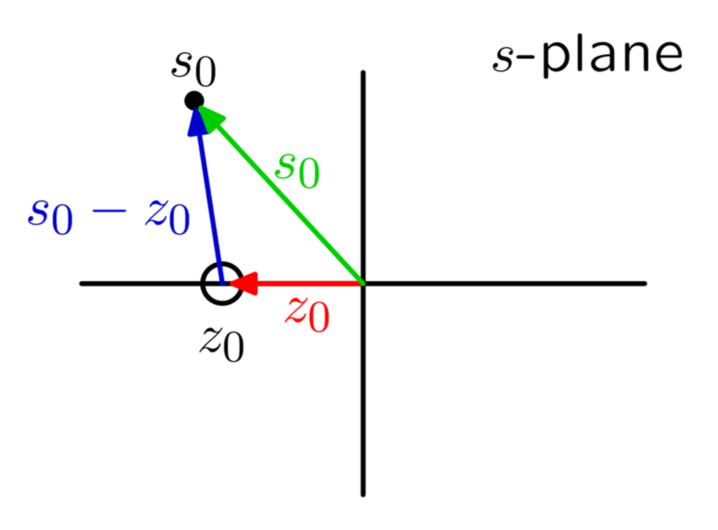

- Each factor in the numerator/denominator corresponds to a vector from a zero/pole (here $z_0$) to $s_0$, the point of interest in the s-plane
- The value of $H(s)$ at a point $s = s_0$ can be determined by combining the contributors of the vectors associated with each of the poles and zeros

$$H(s_0) = K \frac{(s_0 - z_0)(s_0 - z_1)(s_0 - z_2)\cdots}{(s_0 - p_0)(s_0 - p_1)(s_0 - p_2)\cdots}$$

- The magnitude is determined by the product of the magnitudes

$$\lvert H(s_0) \rvert = \lvert K \rvert \frac{\lvert(s_0 - z_0)\rvert \lvert(s_0 - z_1)\rvert \lvert(s_0 - z_2)\rvert \cdots}{\lvert(s_0 - p_0)\rvert \lvert(s_0 - p_1)\rvert \lvert(s_0 - p_2)\rvert \cdots}$$

- The angle is determined by the sum of the angles

$$\angle H(s_0) = \angle K + \angle(s_0 - z_0) + \angle(s_0 - z_1) + \angle(s_0 - z_2) + \cdots - \angle (s_0 - p_0) - \angle(s_0 - p_1) - \angle(s_0 - p_2)- \cdots$$

## 2.4. Vector Diagrams for Frequency Response

- The magnitude and phase of the response of an LTI system to $e^{j \omega t}$ is the magnitude and phase of 𝐻(𝑠) at $s = j \omega$

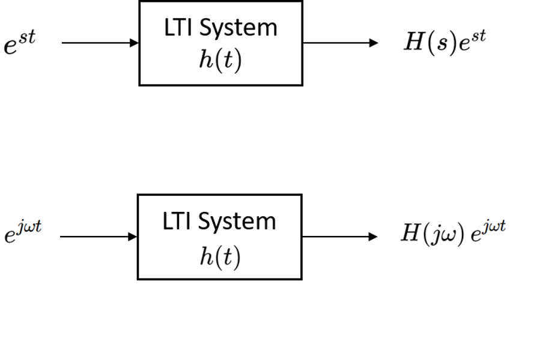

Example: find the response of the system described by
$$H(s) = \frac{1}{s+2}$$ to the input $x(t) = e^{2jt}$

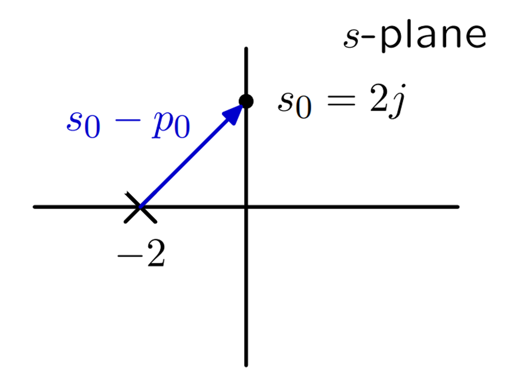

1) Isolated zero $$H(s) = s - z_1$$

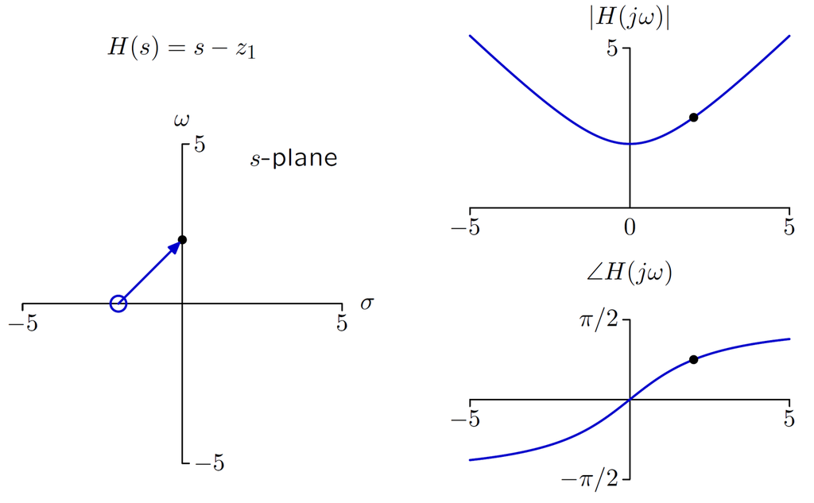

2) Isolated pole

$$H(s) = \frac{9}{s - p_1}$$

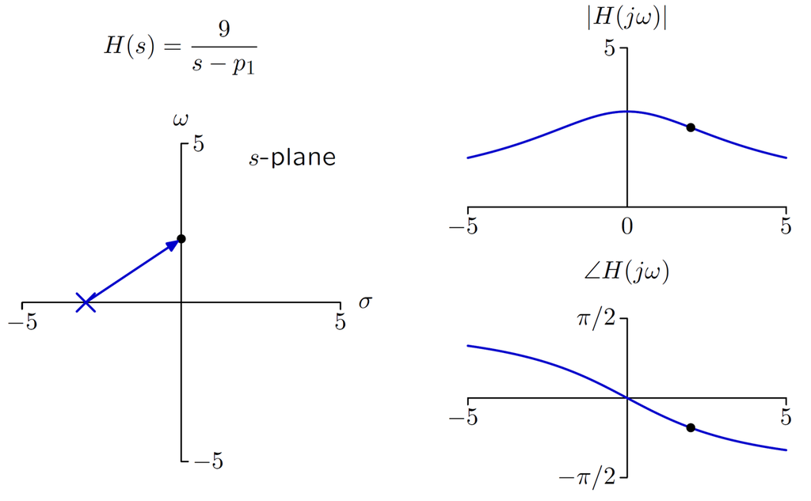

3) More complicated systems: pole and zero

$$H(s) = 3\frac{s-z_1}{s - p_1}$$

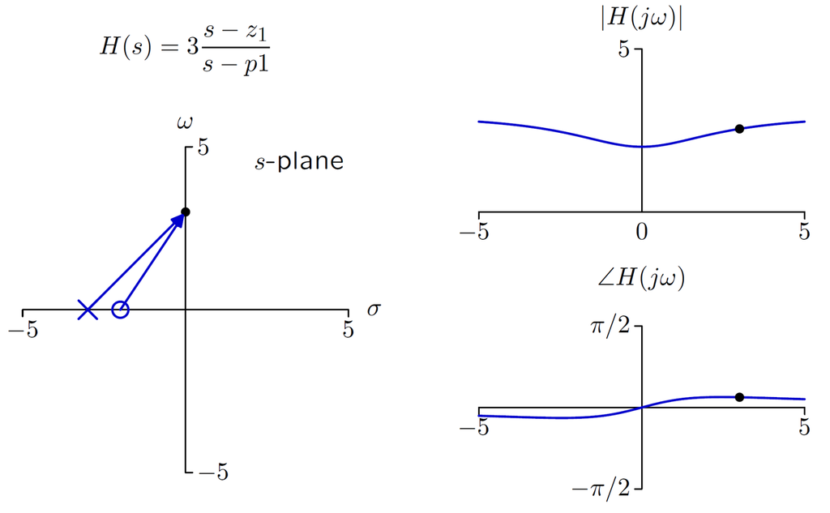

4) More complicated systems: two poles

$$H(s) = \frac{15}{(s-p_1))s - p_2)}$$

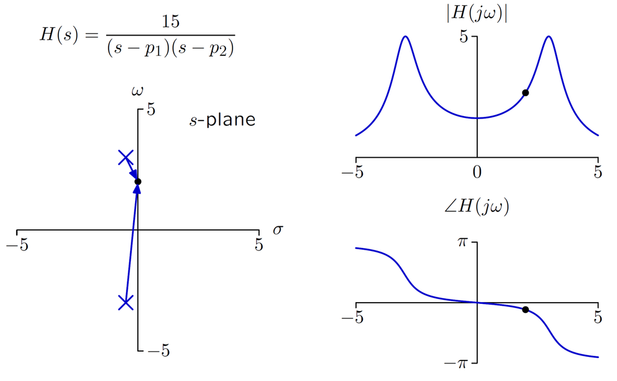

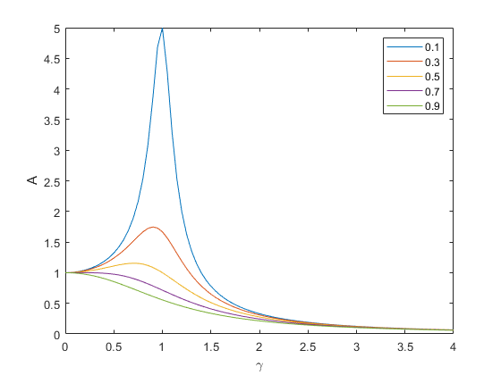

```matlab
r = 0:0.05:4;

zeta = 0.1:0.2:1;
A = [];
for i = 1:length(zeta)
    A(i,:) = 1./sqrt((1-r.^2).^2 + (2*zeta(i)*r).^2);
end

plot(r, A)
xlabel('\gamma')
ylabel('A')
legend('0.1','0.3','0.5','0.7','0.9')
```

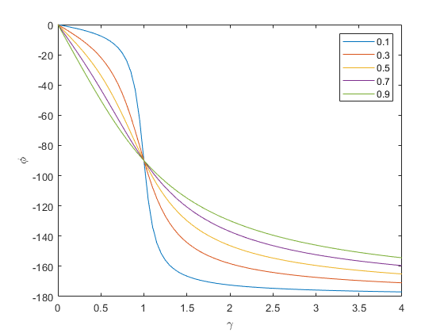

```matlab
phi = [];
for i = 1:length(zeta)
    phi(i,:) = -atan2((2*zeta(i).*r),(1-r.^2));
end

plot(r,phi*180/pi)
xlabel('\gamma')
ylabel('\phi')
legend('0.1','0.3','0.5','0.7','0.9')
```

```matlab
%%html
<center><iframe src="https://www.youtube.com/embed/ZGPtPkTft8g?rel=0"
width="560" height="315" frameborder="0" allowfullscreen></iframe></center>
```

[video not shown]

# 3. Frequency Response and Bode Plots

Frequency response

$$H(j\omega) = H(s) \vert_{s \leftarrow j\omega}$$

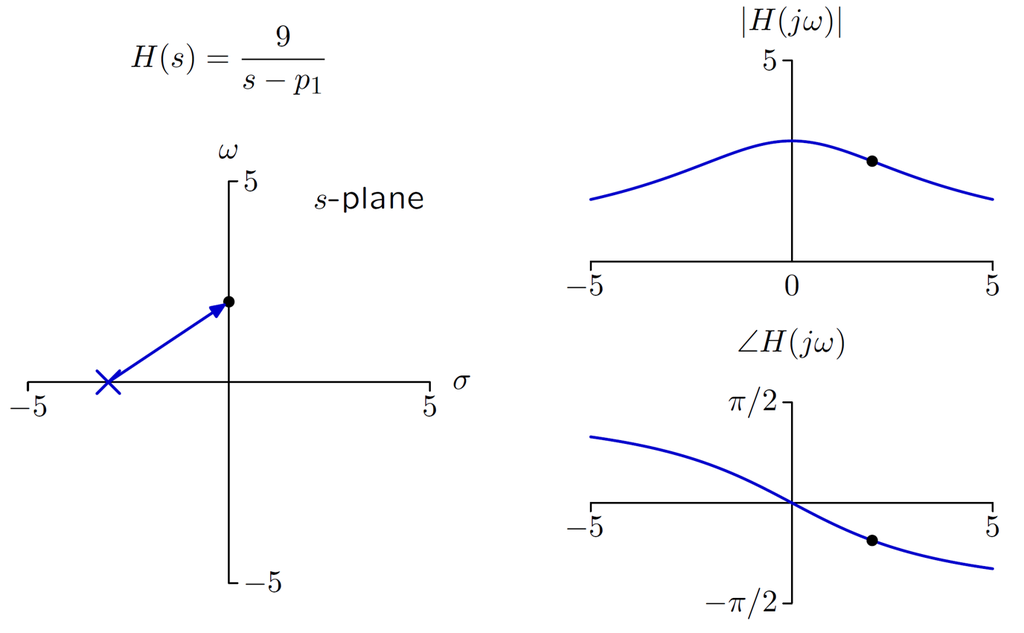

Poles and zeros

- Thinking about systems as collections of poles and zeros is an important design concept.
  - Simple: just a few numbers characterize entire system
  - Powerful: complete information about frequency response

## 3.1. Bode Plots: Magnitude

1) Asymptotic Behavior: Isolated Zero

$$ H(s) = s - z_1$$

- The magnitude response is simple at low and high frequencies

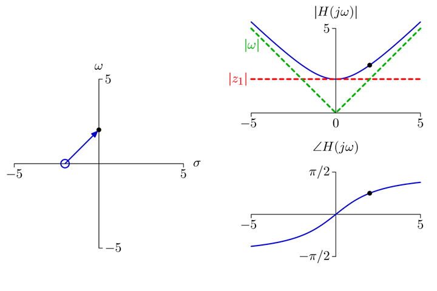

- Two asymptotes provide a good approximation on log-log axes

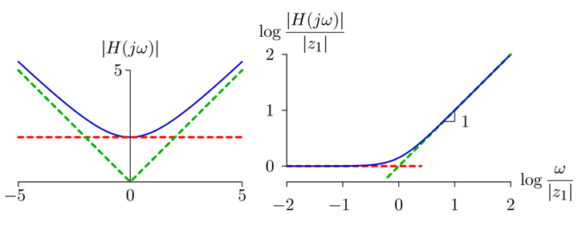

$$ \begin{align*} \lim_{\omega \rightarrow 0} \lvert H(j \omega ) \rvert &= \lvert z_1 \rvert \\\\ \lim_{\omega \rightarrow \infty} \lvert H(j \omega ) \rvert &= \omega \end{align*} $$

2) Asymptotic Behavior: Isolated Pole

$$H(s) = \frac{9}{s - p_1}$$

- The magnitude response is simple at low and high frequencies

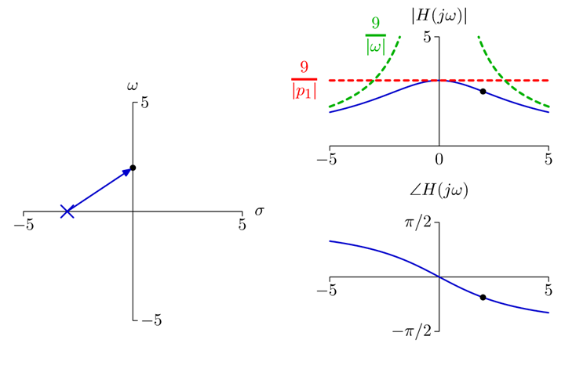

- Two asymptotes provide a good approximation on log-log axes

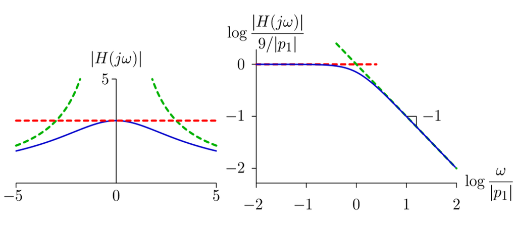

$$ \begin{align*} \lim_{\omega \rightarrow 0} \lvert H(j \omega ) \rvert &= \frac{9}{\lvert p_1 \rvert} \\\\ \lim_{\omega \rightarrow \infty} \lvert H(j \omega ) \rvert &= \frac{9}{\omega} \end{align*} $$

3) Asymptotic Behavior of More Complicated Systems

$$H(s_0) = K \frac{\prod_{m=1}^{M}(s_0 - z_m)}{\prod_{n=1}^{N}(s_0 - p_n)}$$

- The magnitude of a product is the product of the magnitudes

$$ \lvert H(s_0) \rvert = \lvert K \rvert \frac{\prod_{m=1}^{M}\lvert s_0 - z_m \rvert }{\prod_{n=1}^{N} \lvert s_0 - p_n\rvert }$$

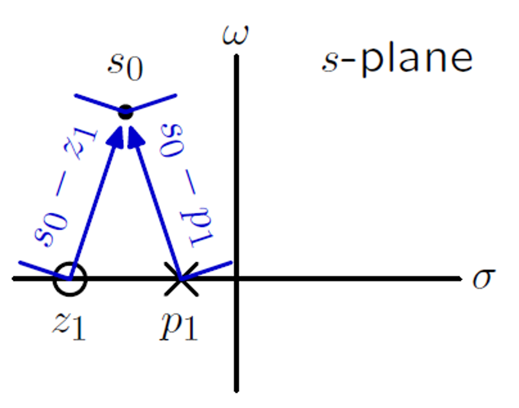

- The log of the magnitude is a sum of logs

$$\log \lvert H(j \omega) \rvert = \log \lvert K \rvert + \sum_{m=1}^{M} \log \lvert j \omega - z_m\rvert - \sum_{n=1}^{N} \log \lvert j \omega - p_n \rvert$$

- Bode Plot: Adding Instead of Multiplying

$$H(s) = \frac{s}{(s+1)(s+10)}$$

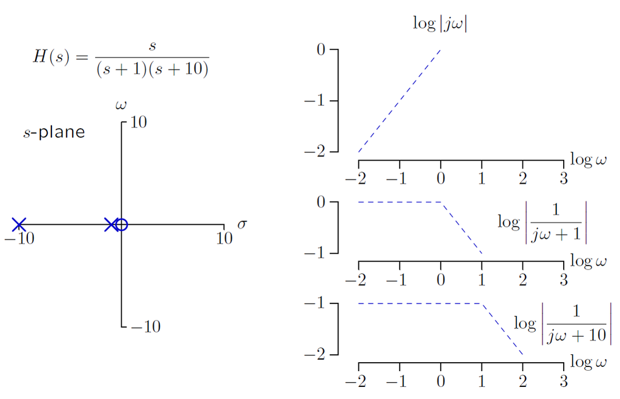

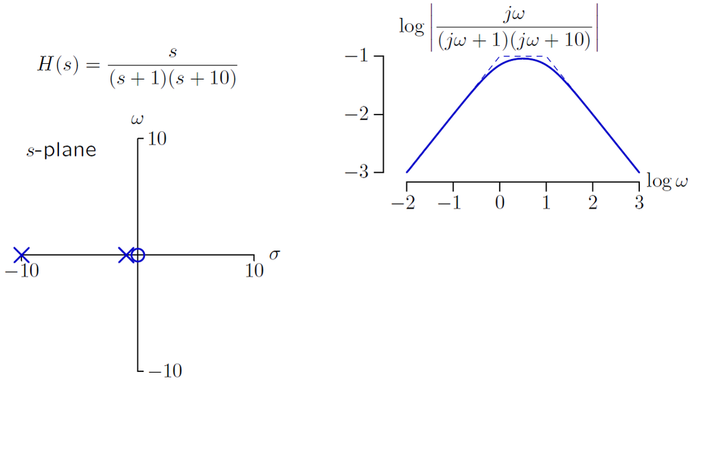